# Behind the graph

The code of my final project, from the raw download to the finding

Jolanta Stutane · SZF_184 Data Visualisation and Storytelling

# The story in one sentence

At the same income, Baltic women live as long as other Europeans.

Baltic men live up to **4.6 years** shorter.

This video shows the code behind that sentence: six tables, five checks, one panel, seventeen exploration graphs, one final graph.

## The pipeline

1 · Gather  
6 tables via API→2 · Clean  
5 checks each→3 · Combine  
gap_panel, 270 rows→4 · Explore  
17 graphs→5 · Final graph  
v1 → v2 → final

`data/raw/` holds the downloads, never edited · `data/clean/` holds what the code makes · every decision is written in the report and in `notes/decisions.md`

# 1 · Gathering the data

From a link to a raw file, by code

## Building the download link

```r
# 2.1.1 The Eurostat API link for life expectancy
life_expectancy_url <- paste0(
  "https://ec.europa.eu/eurostat/api/dissemination/sdmx/2.1/data/",  # the API address
  "demo_mlexpec/",                      # the table code
  "A.YR.F+M.Y_LT1.",                    # annual, in years, women and men, at birth, all countries
  "?startPeriod=2015&endPeriod=2024",   # the study period
  "&format=SDMX-CSV"                    # ask for a CSV file
)

life_expectancy_url  # print the link, so it can also be opened in a browser
```

```
[1] "https://ec.europa.eu/eurostat/api/dissemination/sdmx/2.1/data/demo_mlexpec/A.YR.F+M.Y_LT1.?startPeriod=2015&endPeriod=2024&format=SDMX-CSV"
```

## Download once, and check what came back

```r
# 2.1.2 Save the raw file to data/raw/, only if it isn't there yet
life_expectancy_file <- here("data", "raw", "demo_mlexpec.csv")  # where the raw file goes

if (!file.exists(life_expectancy_file)) {   # TRUE only on the first run
  download.file(life_expectancy_url,        # from this link
                life_expectancy_file,       # to this file
                mode = "wb")                # "wb" copies the file byte for byte
}
```

## Load and look

```r
# 2.1.3 Read the raw file and check what arrived
life_expectancy_raw <- read_csv(life_expectancy_file,
                                na = c("", ":", "NA"),   # Eurostat marks missing values with ":"
                                show_col_types = FALSE)  # keep the output short

glimpse(life_expectancy_raw)  # rows, columns and the type of each column
```

## Load and look

```
Rows: 906
Columns: 11
$ DATAFLOW      <chr> "ESTAT:DEMO_MLEXPEC(1.0)", "ESTAT:DEMO_MLEXPEC(1.0)", "E…
$ `LAST UPDATE` <chr> "25/09/26 23:00:00", "25/09/26 23:00:00", "25/09/26 23:0…
$ freq          <chr> "A", "A", "A", "A", "A", "A", "A", "A", "A", "A", "A", "…
$ unit          <chr> "YR", "YR", "YR", "YR", "YR", "YR", "YR", "YR", "YR", "Y…
$ sex           <chr> "F", "F", "F", "F", "F", "F", "F", "F", "F", "F", "F", "…
$ age           <chr> "Y_LT1", "Y_LT1", "Y_LT1", "Y_LT1", "Y_LT1", "Y_LT1", "Y…
$ geo           <chr> "AL", "AL", "AL", "AL", "AL", "AL", "AL", "AL", "AL", "A…
$ TIME_PERIOD   <dbl> 2015, 2016, 2017, 2018, 2019, 2020, 2021, 2022, 2024, 20…
$ OBS_VALUE     <dbl> 79.7, 80.1, 80.1, 80.5, 80.7, 79.6, 77.7, 80.9, 82.4, 78…
$ OBS_FLAG      <chr> NA, NA, NA, NA, NA, NA, NA, NA, "b", NA, NA, NA, NA, NA,…
$ CONF_STATUS   <lgl> NA, NA, NA, NA, NA, NA, NA, NA, NA, NA, NA, NA, NA, NA, …
```

# 2 · Cleaning

Readable names, and five checks on every table

## Readable names

```r
# 3.1.1 Make the column names readable
life_expectancy_clean <- life_expectancy_raw |>   # start from the untouched raw table
  clean_names() |>                        # for example TIME_PERIOD becomes time_period
  rename(country_code    = geo,           # new name = old name
         year            = time_period,   # the year, a key for the join in Section 4
         life_expectancy = obs_value,     # the value: life expectancy at birth
         flag            = obs_flag)      # e, p, b ... how the value was produced

names(life_expectancy_clean)   # list the new column names
```

```
 [1] "dataflow"        "last_update"     "freq"            "unit"
 [5] "sex"             "age"             "country_code"    "year"
 [9] "life_expectancy" "flag"            "conf_status"
```

## Five checks on every table · the flags

```r
# 3.1.2 Check 2: how many values carry a flag, and which one
life_expectancy_clean |>
  count(flag, sort = TRUE) |>                     # most common flag first
  kable(col.names = c("Flag", "Number of values"))  # NA here means "no flag"
```

| Flag | Number of values |
| --- | --- |
| NA | 760 |
| b | 66 |
| e | 28 |
| ep | 16 |
| bep | 12 |
| be | 10 |
| p | 10 |
| bp | 4 |

## Five checks · the range

```r
# 3.1.2 Check 3: the distribution of life expectancy values, women and men apart
life_expectancy_clean |>
  ggplot(aes(x = life_expectancy, fill = sex)) +     # one number, so a histogram (class 10_1)
  geom_histogram(binwidth = 1,
                 color = "white") +                  # one bar per year, white gaps between bars
  scale_fill_viridis_d(begin = 0.25, end = 0.75) +   # course palette: blue for women, green for men
  geom_vline(xintercept = c(65, 90),
             linetype = "dashed") +                  # the expected range
  facet_wrap(~ sex,
             labeller = as_labeller(c(F = "Women", M = "Men"))) +   # one panel per sex
  labs(title = "All values lie inside the expected range of 65 to 90 years",   # the title states the finding
       x = "Life expectancy at birth (years)",
       y = "Number of rows") +
  theme_minimal() +                                  # white background, light grid
  theme(legend.position = "none",                    # the panel titles already name the sexes
        panel.grid.minor = element_blank())          # fewer lines that carry no data
```

## Five checks · the range

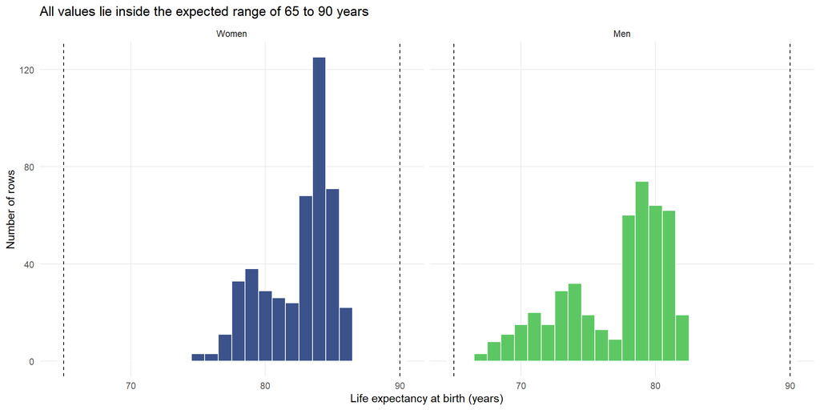

## Five checks · the row counts

```r
# 3.1.2 Check 5: number of rows per geographic unit, EU member states in orange
life_expectancy_clean |>
  count(country_code) |>                                  # n = number of rows per unit
  mutate(eu = country_code %in% eu_codes,                 # TRUE for the 27 member states
         country_code = fct_reorder(country_code, n)) |>  # sort the bars by n
  ggplot(aes(x = country_code, y = n, fill = eu)) +      # one bar per unit, coloured by EU or not
  geom_col() +                                            # bar length = the number of rows
  geom_hline(yintercept = 20, linetype = "dashed") +      # the expected 20 rows
  coord_flip() +                                          # bars sideways, codes readable
  scale_fill_viridis_d(option = "plasma",
                       begin = 0.15, end = 0.75,                    # purple and orange, no red
                       labels = c("Other unit", "EU member state"), # FALSE comes first, then TRUE
                       name = NULL) +
  labs(title = "Every EU member state has all 20 rows",   # the title states the finding
       x = NULL,                                         # the country codes need no axis title
       y = "Number of rows (expected: 20)") +
  theme_minimal() +                                  # white background, light grid
  theme(legend.position = "top",
        panel.grid.minor = element_blank(),
        panel.grid.major.y = element_blank())              # the bars need no horizontal grid
```

## Five checks · the row counts

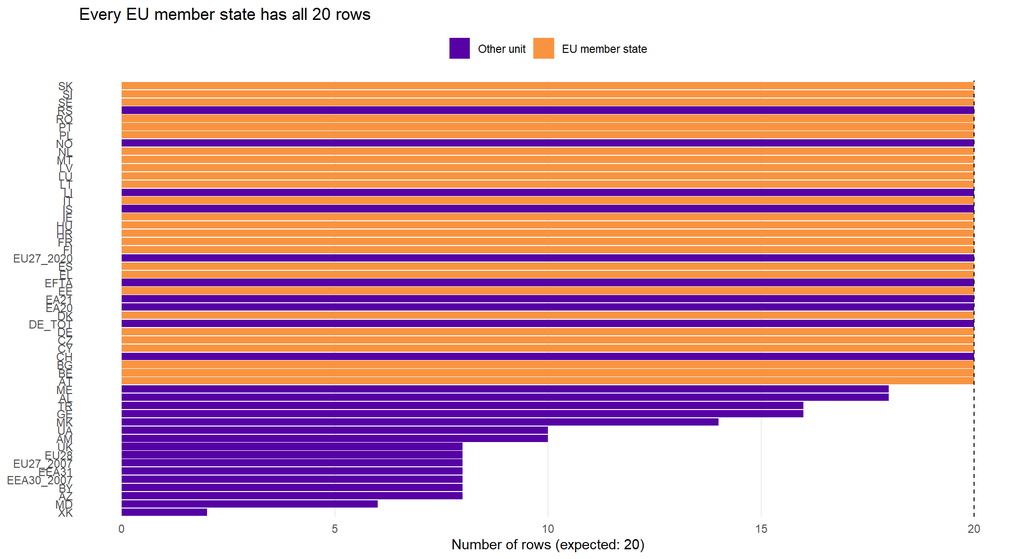

## Apply the decisions

```r
# 3.1.4 Keep only the 27 EU member states
nrow(life_expectancy_clean)   # before: 906 rows
```

```
[1] 906
```

```r
life_expectancy_clean <- life_expectancy_clean |>
  filter(country_code %in% eu_codes)   # drop non-EU countries and aggregates such as EU27_2020

nrow(life_expectancy_clean)   # after: expected 27 x 2 x 10 = 540
```

```
[1] 540
```

# 3 · Combining the tables

Six tables become one panel of 270 rows

## Women and men side by side

```r
# 4.1.1 Life expectancy: women and men side by side, then the gap
life_expectancy_wide <- life_expectancy_clean |>   # start from the clean table of 3.1
  select(-flag) |>                                 # drop the flags, they are described in Section 3
  pivot_wider(names_from  = sex,                   # the values F and M become column names
              values_from = life_expectancy) |>    # the numbers fill the new columns
  rename(le_women = F,                             # new name = old name
         le_men   = M) |>
  mutate(le_gap = le_women - le_men)               # the gap: women minus men, in years

glimpse(life_expectancy_wide)   # expected: 270 rows, 5 columns
```

```
Rows: 270
Columns: 5
$ country_code <chr> "AT", "AT", "AT", "AT", "AT", "AT", "AT", "AT", "AT", "AT…
$ year         <dbl> 2015, 2016, 2017, 2018, 2019, 2020, 2021, 2022, 2023, 202…
$ le_women     <dbl> 83.6, 84.0, 83.9, 84.0, 84.2, 83.7, 83.7, 83.8, 84.2, 84.…
$ le_men       <dbl> 78.6, 79.1, 79.3, 79.3, 79.5, 78.9, 78.8, 79.0, 79.4, 79.…
$ le_gap       <dbl> 5.0, 4.9, 4.6, 4.7, 4.7, 4.8, 4.9, 4.8, 4.8, 4.5, 4.6, 4.…
```

## Joining, and checking every join

```r
# 4.3.1 Add healthy life years to the life expectancy table
gap_panel <- life_expectancy_wide |>                       # the backbone: 270 rows
  left_join(healthy_life_years_wide,                       # add the healthy life years columns
            by = join_by(country_code, year))              # match on country and year

nrow(gap_panel)   # must still be 270
```

```
[1] 270
```

```r
life_expectancy_wide |>
  anti_join(healthy_life_years_wide,                       # rows of the backbone with no partner
            by = join_by(country_code, year)) |>
  select(country_code, year) |>                            # only the keys are needed here
  kable()                                                  # expected: Luxembourg 2023 and 2024
```

| country_code | year |
| --- | --- |
| LU | 2023 |
| LU | 2024 |

## The join that shows a missing year

```r
# 4.3.4 Add deaths from all causes
gap_panel <- gap_panel |>                                  # the panel so far
  left_join(deaths_all_causes,                             # add the deaths columns
            by = join_by(country_code, year))              # match on country and year

nrow(gap_panel)   # must still be 270
```

```
[1] 270
```

```r
gap_panel |>
  anti_join(deaths_all_causes, by = join_by(country_code, year)) |>   # rows with no deaths data
  count(year)                                                         # expected: only 2024, 27 rows
```

```
# A tibble: 1 × 2
   year     n
  <dbl> <int>
1  2024    27
```

## The panel is ready

```r
# 4.4 Add the country names and mark the Baltic states
gap_panel <- gap_panel |>                                   # the panel after the four joins
  left_join(country_names, by = join_by(country_code)) |>   # add the name, matched on the code only
  mutate(baltic = country_code %in% c("EE", "LV", "LT")) |> # TRUE for Estonia, Latvia, Lithuania
  select(country_code, country, baltic, everything())       # put the three columns first, then all others

nrow(gap_panel)          # must still be 270
```

```
[1] 270
```

```r
sum(is.na(gap_panel$country))   # expected: 0, every code found its name
```

```
[1] 0
```

```r
gap_panel |>
  count(baltic) |>                                          # rows per group
  kable(col.names = c("Baltic state", "Rows"))              # expected: FALSE 240, TRUE 30
```

| Baltic state | Rows |
| --- | --- |
| FALSE | 240 |
| TRUE | 30 |

# 4 · Exploring

Where is the gap, and what goes with it?

## Where is the gap largest?

```r
# 5.1.1 Graph 1: the life expectancy gap in 2024, country by country
gap_2024 <- gap_panel |>
  filter(year == 2024)                                       # the latest year only, one row per country

gap_2024 |>
  mutate(country = fct_reorder(country, le_gap)) |>          # sort the countries by their gap
  ggplot(aes(x = country, y = le_gap, fill = baltic)) +      # one bar per country, coloured by Baltic or not
  geom_col() +                                               # bar length = the gap in years
  geom_hline(yintercept = mean(gap_2024$le_gap),
             linetype = "dashed") +                          # the EU average of the 27 gaps
  coord_flip() +                                             # bars sideways, names readable
  scale_fill_manual(values = c("TRUE" = "firebrick",         # Baltic states in red
                               "FALSE" = "gray70")) +        # all other countries in gray
  labs(title = "Women outlive men by the most years in the three Baltic states",   # the title states the finding
       x = NULL,                                             # the country names need no axis title
       y = "Life expectancy gap in 2024, women minus men (years)",
       caption = "Dashed line: EU average of the 27 countries. Source: Eurostat, demo_mlexpec") +
  theme_minimal() +                                          # white background, light grid
  theme(legend.position = "none",                            # red and gray are explained in the title
        panel.grid.minor = element_blank(),
        panel.grid.major.y = element_blank())                # the bars need no horizontal grid
```

## Where is the gap largest?

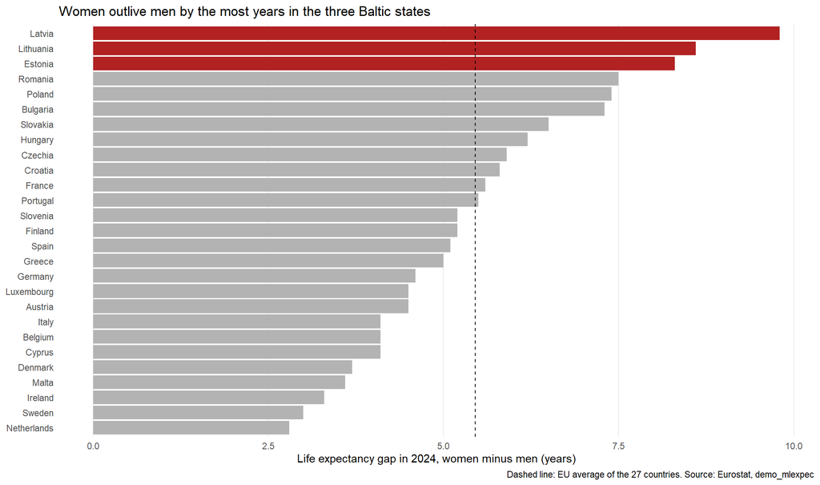

## Has the gap changed?

```r
# 5.2.1 Graph 4: the life expectancy gap over time, one line per country
gap_panel |>
  ggplot(aes(x = year, y = le_gap, group = country,         # one line per country
             colour = baltic)) +                            # red for the Baltic states, gray for the rest
  geom_line(aes(linewidth = baltic)) +                      # thicker lines for the Baltic states
  geom_text_repel(data = gap_panel |>
                    filter(baltic, year == 2024),           # labels only for the Baltic states, at the last year
                  aes(label = country),
                  nudge_x = 0.6, direction = "y",           # labels to the right of the lines, spread up and down
                  hjust = 0, segment.colour = NA) +         # no connecting line, the label sits next to its line
  scale_colour_manual(values = c("TRUE" = "firebrick",      # Baltic states in red
                                 "FALSE" = "gray70")) +     # all other countries in gray
  scale_linewidth_manual(values = c("TRUE" = 1.2,           # thick Baltic lines
                                    "FALSE" = 0.4)) +       # thin lines for the others
  scale_x_continuous(breaks = 2015:2024,                    # one tick per year
                     limits = c(2015, 2025.5)) +            # room on the right for the labels
  labs(title = "Lithuania narrowed its gap the most, while Latvia's gap did not shrink",   # the title states the finding
       x = NULL,
       y = "Life expectancy gap, women minus men (years)",
       caption = "The y axis does not start at zero. Source: Eurostat, demo_mlexpec") +
  theme_minimal() +                                         # white background, light grid
  theme(legend.position = "none",                           # the labels name the red lines
        panel.grid.minor = element_blank())                 # fewer lines that carry no data
```

## Has the gap changed?

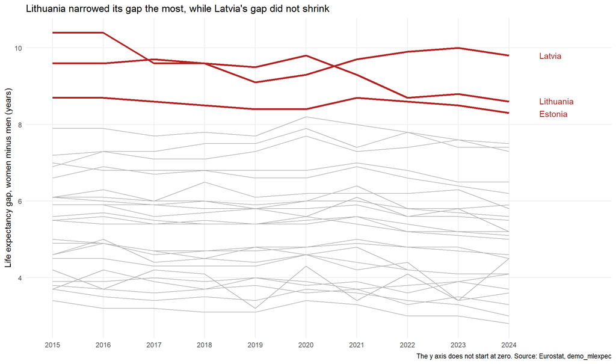

## Which deaths make up the gap?

```r
# 5.3.1 Graph 5: the extra deaths of men by chapter of causes, Baltic states and rest of the EU, 2023
chapter_gap <- deaths_by_cause |>
  filter(cause_level == "chapter", year == 2023) |>                    # the chapters, latest year
  mutate(chapter = case_when(                                          # short readable names
    cause_code == "I"       ~ "Circulatory (heart, stroke)",
    cause_code == "V01-Y89" ~ "External (accidents, suicide)",
    cause_code == "C00-D48" ~ "Cancer and other tumours",
    cause_code == "K"       ~ "Digestive (incl. liver)",
    cause_code == "J"       ~ "Respiratory",
    cause_code == "R"       ~ "Ill-defined causes",
    cause_code == "A_B"     ~ "Infectious",
    cause_code == "G_H"     ~ "Nervous system",
    cause_code == "E"       ~ "Endocrine (incl. diabetes)",
    cause_code == "F"       ~ "Mental (incl. alcohol use)",
    cause_code %in% c("U071", "U072", "U_COV19_OTH") ~ "COVID-19",
    .default = "Other chapters"                                        # the small chapters together
  )) |>
  group_by(country, baltic, chapter) |>                                # first add up per country
  summarise(death_gap = sum(death_gap), .groups = "drop") |>           # (COVID and the small chapters have several codes)
  group_by(baltic, chapter) |>                                         # then average per group
  summarise(death_gap = mean(death_gap), .groups = "drop") |>          # simple average of the countries
  mutate(group = if_else(baltic, "Baltic states", "Rest of the EU"))   # readable group names

chapter_gap |>
  mutate(chapter = fct_reorder(chapter, death_gap, .fun = max)) |>     # sort the chapters by their larger bar
  ggplot(aes(x = chapter, y = death_gap, fill = group)) +
  geom_col(position = "dodge") +                                       # the two groups side by side
  coord_flip() +                                                       # bars sideways, names readable
  scale_fill_manual(values = c("Baltic states" = "firebrick",          # Baltic states in red
                               "Rest of the EU" = "gray70")) +         # the rest in gray
  labs(title = "Heart and external causes lead the extra deaths of Baltic men",   # the finding, short enough to fit
       subtitle = "Extra deaths of men under 65 compared with women, by chapter of causes, 2023",   # what is shown
       x = NULL,
       y = "Extra deaths of men under 65 per 100 000 (men minus women), 2023",
       fill = NULL,
       caption = "Average of the countries in each group. Source: Eurostat, hlth_cd_asdr2") +
  theme_minimal() +                                                    # white background, light grid
  theme(legend.position = "top",                                       # two groups, so a legend is needed
        panel.grid.minor = element_blank(),
        panel.grid.major.y = element_blank())                          # the bars need no horizontal grid
```

## Which deaths make up the gap?

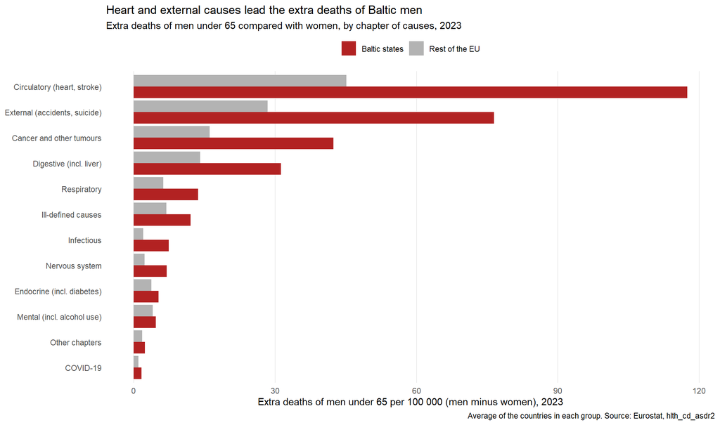

## Which factors go with the gap?

```r
# 5.4.2 Graph 7: the gap against men's extra deaths from circulatory diseases, 2023
factors_2023 |>
  ggplot(aes(x = death_circulatory, y = le_gap)) +          # one dot per country
  geom_smooth(method = "lm", formula = y ~ x, se = FALSE,
              colour = "gray40", linewidth = 0.6) +         # the straight trend line (y depends on x), without a band
  geom_point(aes(colour = baltic), size = 2.5) +            # the countries, Baltic states in red
  geom_text_repel(data = factors_2023 |> filter(baltic),    # names only for the Baltic states
                  aes(label = country), colour = "firebrick",
                  nudge_y = -0.4) +                         # labels slightly below the dots, away from the top edge
  scale_colour_manual(values = c("TRUE" = "firebrick",
                                 "FALSE" = "gray60")) +
  coord_cartesian(clip = "off") +                           # let the labels go past the edge of the panel
  labs(title = "Where more men die early of heart disease, the gap is larger",   # the title states the pattern
       x = "Extra deaths of men from circulatory diseases, under 65 (per 100 000, men minus women)",
       y = "Life expectancy gap (years)",
       caption = "One dot per EU country, 2023. Source: Eurostat") +
  theme_minimal() +
  theme(legend.position = "none",
        panel.grid.minor = element_blank())
```

## Which factors go with the gap?

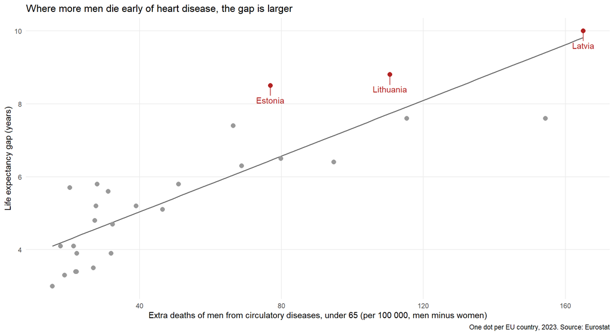

## All factors, in numbers

```r
# 5.4.7 The correlation of each factor with the gap, with and without the Baltic states
factors_long |>
  group_by(factor) |>                                                   # once per factor
  summarise(r_all         = cor(value, le_gap),                         # all 27 countries
            r_not_baltic  = cor(value[!baltic], le_gap[!baltic]),       # the 24 other countries
            .groups = "drop") |>
  kable(digits = 2,                                                     # two decimals for correlations
        col.names = c("Factor", "Correlation, all 27", "Without the Baltic states"))
```

| Factor | Correlation, all 27 | Without the Baltic states |
| --- | --- | --- |
| 1 Circulatory deaths, men’s excess | 0.87 | 0.81 |
| 2 External deaths, men’s excess | 0.91 | 0.85 |
| 3 Alcohol-related deaths, men’s excess | 0.88 | 0.83 |
| 4 GDP per capita (EU27 = 100) | -0.61 | -0.65 |
| 5 Education gap (women minus men, % points) | 0.52 | 0.22 |

## Could it be chance?

```r
# 5.9.1 Correlation, 95% confidence interval and p-value for each factor, in 2019 and 2023
factors_long_all |>
  filter(year %in% c(2019, 2023)) |>                                   # the last year before COVID-19 and the latest year
  group_by(factor, year) |>                                            # once per factor and year
  summarise(r       = cor.test(value, le_gap)$estimate,                # the correlation
            ci_low  = cor.test(value, le_gap)$conf.int[1],             # lower end of the 95% confidence interval
            ci_high = cor.test(value, le_gap)$conf.int[2],             # upper end
            p_value = cor.test(value, le_gap)$p.value,                 # the probability of this by chance
            .groups = "drop") |>
  arrange(factor, year) |>
  kable(digits = c(0, 0, 2, 2, 2, 4),                                  # decimals per column
        col.names = c("Factor", "Year", "Correlation", "95% CI, low", "95% CI, high", "p-value"))
```

| Factor | Year | Correlation | 95% CI, low | 95% CI, high | p-value |
| --- | --- | --- | --- | --- | --- |
| death_alcohol | 2019 | 0.80 | 0.61 | 0.91 | 0.0000 |
| death_alcohol | 2023 | 0.88 | 0.75 | 0.94 | 0.0000 |
| death_circulatory | 2019 | 0.85 | 0.70 | 0.93 | 0.0000 |
| death_circulatory | 2023 | 0.87 | 0.73 | 0.94 | 0.0000 |
| death_external | 2019 | 0.91 | 0.82 | 0.96 | 0.0000 |
| death_external | 2023 | 0.91 | 0.81 | 0.96 | 0.0000 |
| gdp_pps_index | 2019 | -0.53 | -0.76 | -0.19 | 0.0045 |
| gdp_pps_index | 2023 | -0.61 | -0.80 | -0.30 | 0.0008 |
| tertiary_gap | 2019 | 0.47 | 0.11 | 0.72 | 0.0139 |
| tertiary_gap | 2023 | 0.52 | 0.17 | 0.75 | 0.0057 |

# 5 · The final graph

Version 1, version 2, final

## Version 1 → version 2 → final

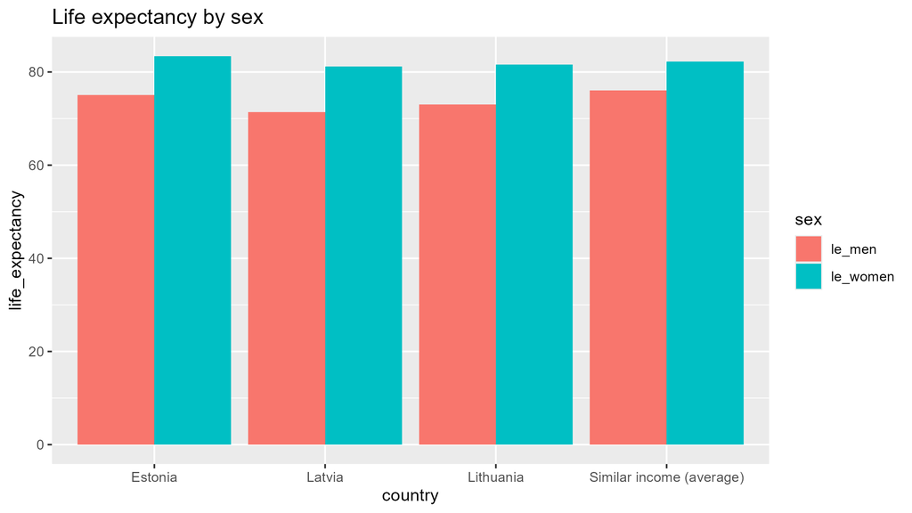

Version 1: bars from 0 hide the gap

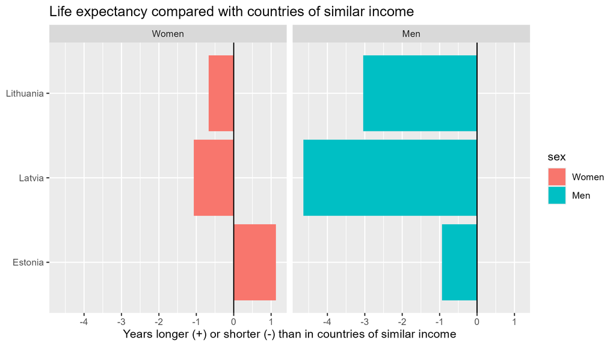

Version 2: the difference makes it visible

## The final graph

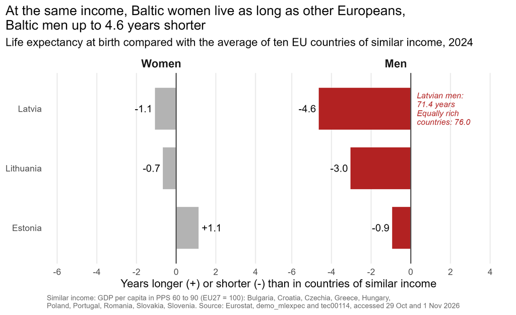

At the same income, **Baltic women keep up with Europe.**

**Baltic men don’t**, and in Latvia they live **4.6 years** shorter.

Six tables · five checks each · one panel of 270 rows · seventeen exploration graphs · one final graph